# GAM

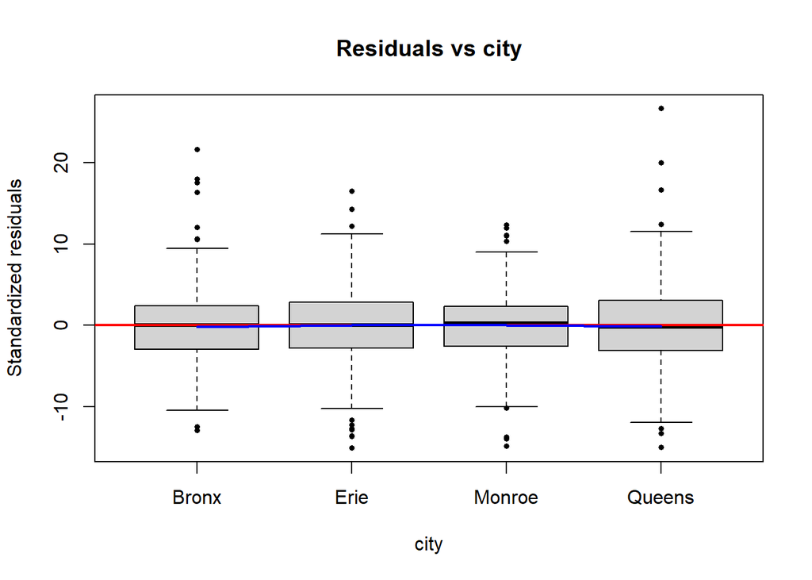

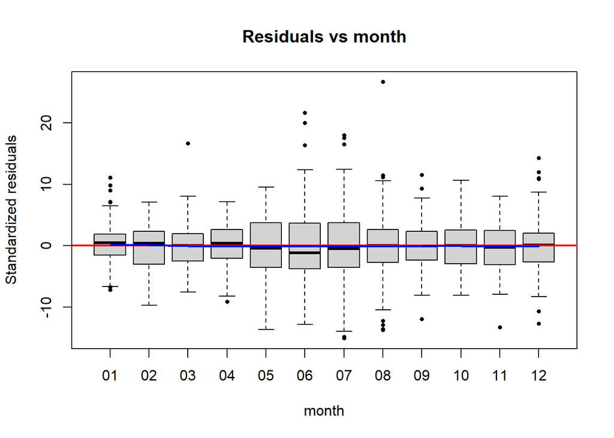

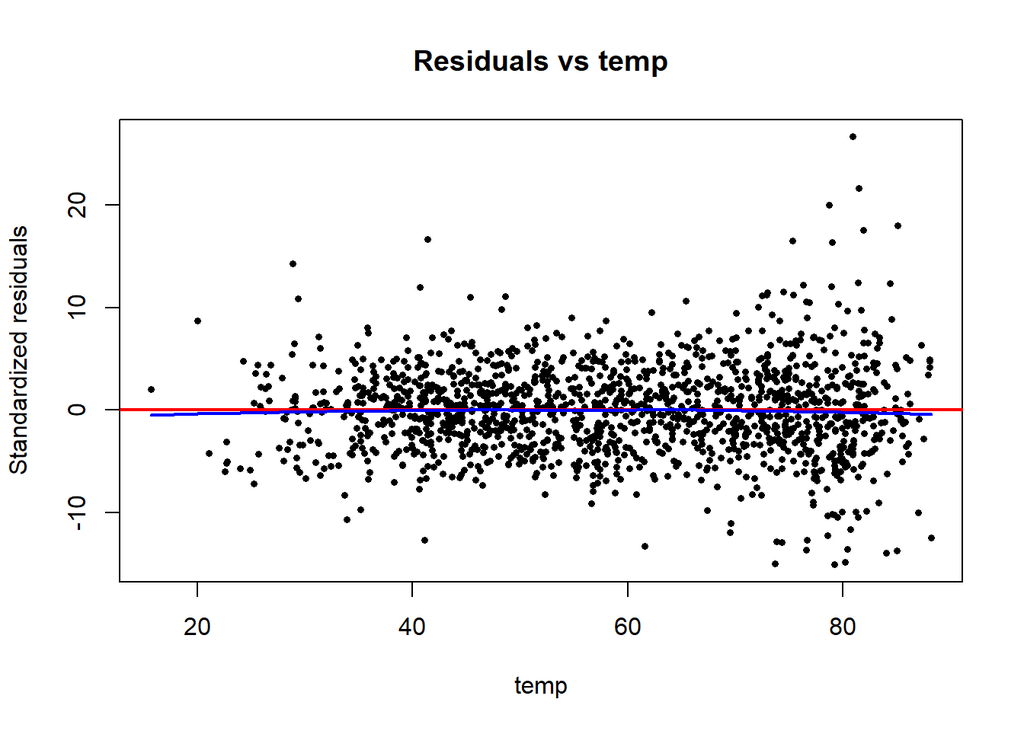

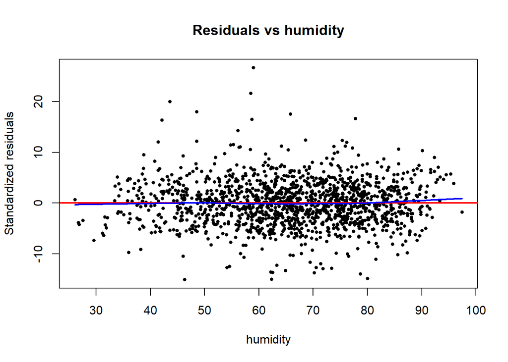

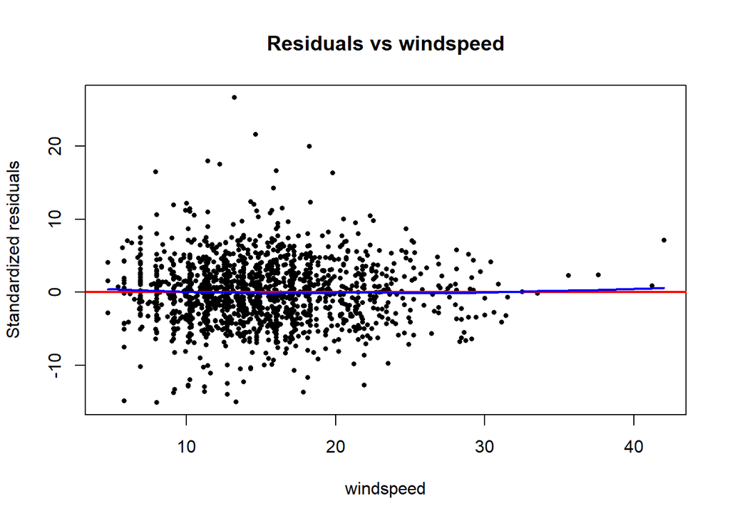

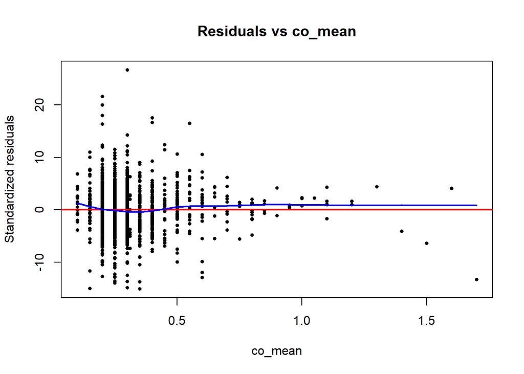

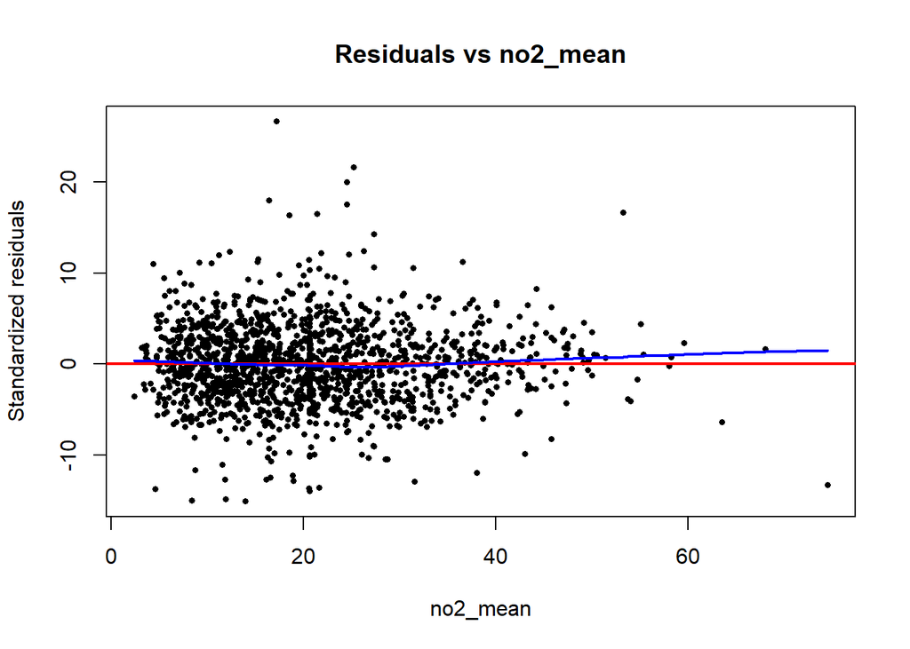

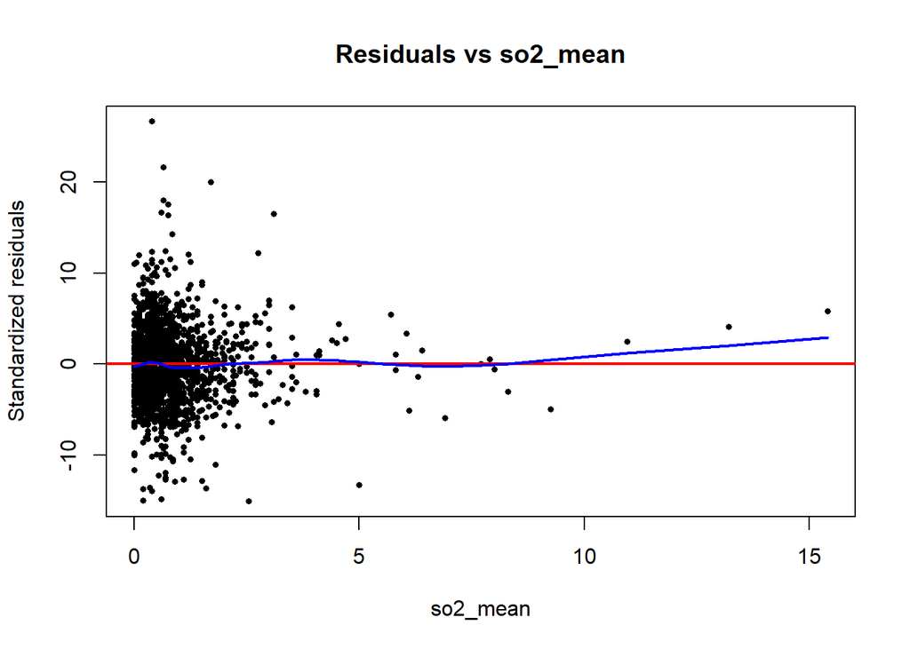

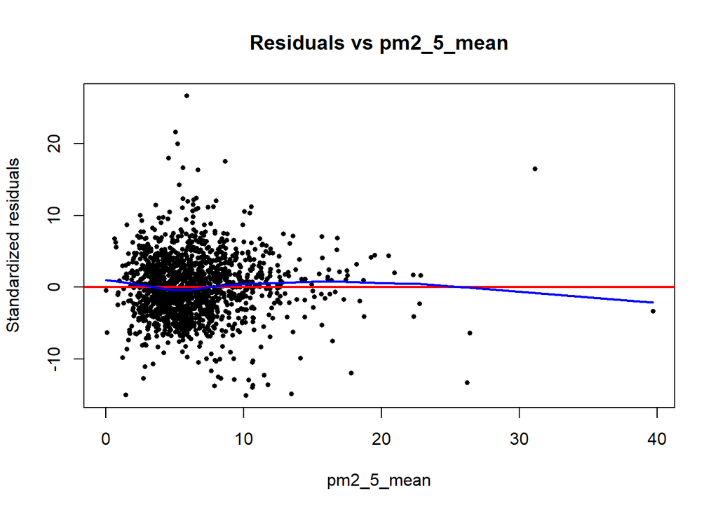

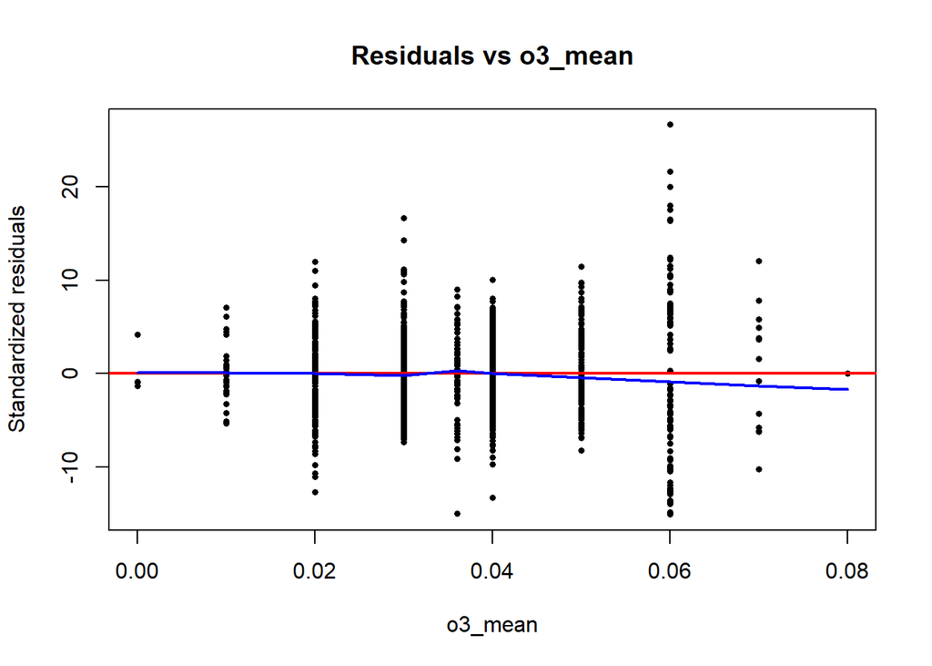

```r
# 3) residuals vs predictors (one by one)

train_full$city <- factor(train_full$city)
Xcols <- c("city", "month", "temp","humidity","windspeed",
           "co_mean","no2_mean","so2_mean","pm2_5_mean","o3_mean")

for (x in Xcols) {
  xx <- train_full[[x]]
  ok <- is.finite(xx) & is.finite(rstd_gam)

  plot(xx[ok], rstd_gam[ok], pch=16, cex=0.6,
       xlab=x, ylab="Standardized residuals",
       main=paste("Residuals vs", x))
  abline(h=0, col="red", lwd=2)
  lines(lowess(xx[ok], rstd_gam[ok]), col="blue", lwd=2)
}
```

```r
pred_gam_pw_o3_temp <- predict(fit_gam_pw_o3_temp, newdata = test_full)

rmse_fit_gam_pw_o3_temp <- rmse(test_full$max_aqi, pred_gam_pw_o3_temp)
rmse_fit_gam_pw_o3_temp
```

```
## [1] 5.075457
```

A great improvement on rmse, it is decreased a lot after including *O3* and **temp** interaction.

```r
resid_gam_pw_o3_temp <- test_full$max_aqi - pred_gam_pw_o3_temp
rse_fit_gam_pw_o3_temp <- sqrt(sum(resid_gam_pw_o3_temp^2, na.rm = TRUE) / (sum(!is.na(resid_gam_pw_o3_temp)) - 1))
rse_fit_gam_pw_o3_temp
```

```
## [1] 5.077191
```

# 9 GAM interaction 3

```r
fit_gam_int3 <- gam(max_aqi ~ city +
                    s(o3_mean, k=10) +
                    s(temp, k=5) +
                    s(pm2_5_mean, k=8) +
                    ti(o3_mean, pm2_5_mean, k=c(10, 8)) +
                    ti(month_num, temp, k=c(12,5)) +
                    no2_mean + co_mean + so2_mean + humidity + windspeed,
                    data = train_full)
summary(fit_gam_int3)
```

```
##
## Family: gaussian
## Link function: identity
##
## Formula:
## max_aqi ~ city + s(o3_mean, k = 10) + s(temp, k = 5) + s(pm2_5_mean,
##     k = 8) + ti(o3_mean, pm2_5_mean, k = c(10, 8)) + ti(month_num,
##     temp, k = c(12, 5)) + no2_mean + co_mean + so2_mean + humidity +
##     windspeed
##
## Parametric coefficients:
##              Estimate Std. Error t value Pr(>|t|)
## (Intercept) 44.703429   0.847819  52.728  < 2e-16 ***
## cityErie    -2.936726   0.319275  -9.198  < 2e-16 ***
## cityMonroe  -1.798961   0.352431  -5.104 3.78e-07 ***
## cityQueens  -1.276654   0.286949  -4.449 9.32e-06 ***
## no2_mean     0.038820   0.015227   2.549   0.0109 *
## co_mean     -1.766363   1.038184  -1.701   0.0891 .
## so2_mean    -0.074234   0.101923  -0.728   0.4665
## humidity     0.005914   0.008404   0.704   0.4818
## windspeed    0.025424   0.022111   1.150   0.2504
## ---
## Signif. codes:  0 '***' 0.001 '**' 0.01 '*' 0.05 '.' 0.1 ' ' 1
##
## Approximate significance of smooth terms:
##                           edf Ref.df       F p-value
## s(o3_mean)              7.124  7.270  89.836  <2e-16 ***
## s(temp)                 1.000  1.000   6.075  0.0138 *
## s(pm2_5_mean)           5.950  6.522 557.689  <2e-16 ***
## ti(o3_mean,pm2_5_mean) 39.027 42.662  19.661  <2e-16 ***
## ti(month_num,temp)     17.339 21.993   3.465  <2e-16 ***
## ---
## Signif. codes:  0 '***' 0.001 '**' 0.01 '*' 0.05 '.' 0.1 ' ' 1
##
## R-sq.(adj) =  0.933   Deviance explained = 93.7%
## GCV = 14.017  Scale est. = 13.257    n = 1464
```

**Interpreting the “Parametric coefficients”**:

- **Intercept = 44.70** When every numerical predictor is zero, this is the expected max_aqi for the reference city, the Bronx. The intercept is mostly a baseline anchor rather than a significant “real-day” AQI since “zero” is unrealistic for variables like humidity and temperature.

**City effects (relative to Bronx)**

Therefore, Bronx continues to have the highest baseline among these even after controlling for weather and pollution. That can be easily understood by the plot “city vs max_aqi plot of 2020 vs 2024”.

**Linear pollutant/weather terms**

- **no2_mean = +0.0388 (p = 0.0109)**: statistically significant positive effect; after adjusting for other predictors, increased **no2_mean** has been associated to higher AQI.
- **co_mean = -1.76 (p ≈ 0.08)**: borderline; Instead of a real “protective” effect, a negative sign can indicate collinearity or shared variation with PM2.5 and ozone.
- **so2_mean, humidity, windspeed**: not significant here because p_values are very large.

**Smooths**

Very small p-values indicate the smooth term is needed.

mgcv provides an approximate F-test for whether each smooth term contributes beyond noise. Here, in this model, **s(pm2_5_mean)** contributes the most and then **s(o3_mean)**.

**Model fit statistics**

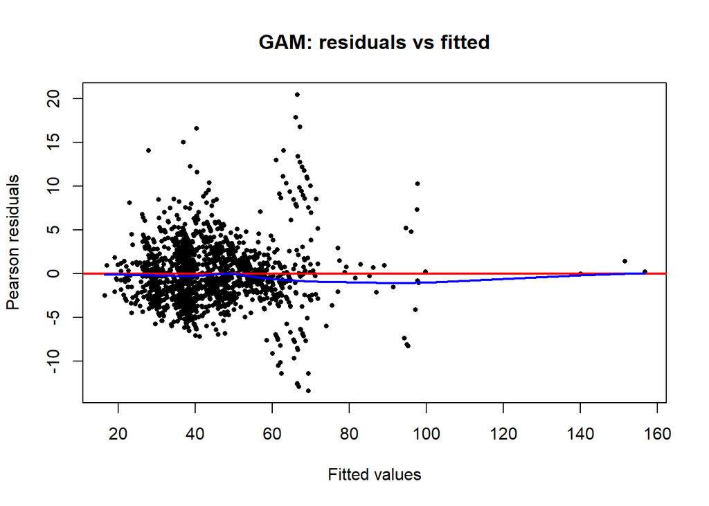

```r
rstd_gam_int3 <- residuals(fit_gam_int3, type = "pearson")
yhat_gam_int3 <- fitted(fit_gam_int3)
n_gam_int3   <- length(rstd_gam_int3)

# 2) residuals vs fitted values
ok <- is.finite(yhat_gam) & is.finite(rstd_gam_int3)
plot(yhat_gam_int3[ok], rstd_gam_int3[ok], pch=16, cex=0.6,
     xlab="Fitted values", ylab="Pearson residuals",
     main="GAM: residuals vs fitted")
abline(h=0, col="red", lwd=2)
lines(lowess(yhat_gam_int3[ok], rstd_gam_int3[ok]), col="blue", lwd=2)
```

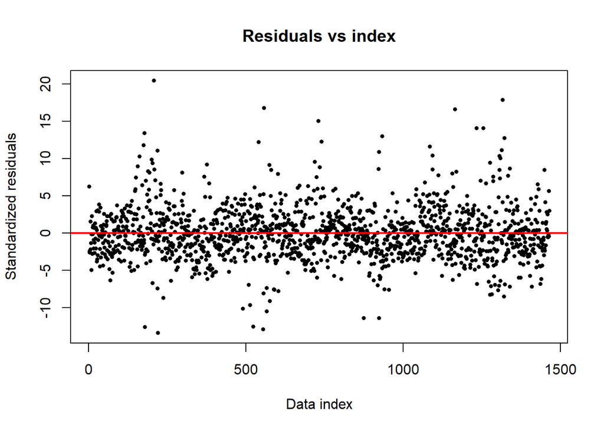

```r
# 1) residuals vs data index
plot(1:n_gam_int3, rstd_gam_int3, pch=16, cex=0.6,
     xlab="Data index", ylab="Standardized residuals",
     main="Residuals vs index")
abline(h=0, col="red", lwd=2)
```

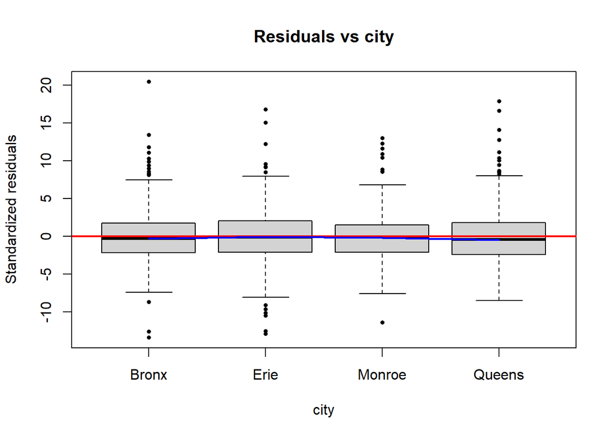

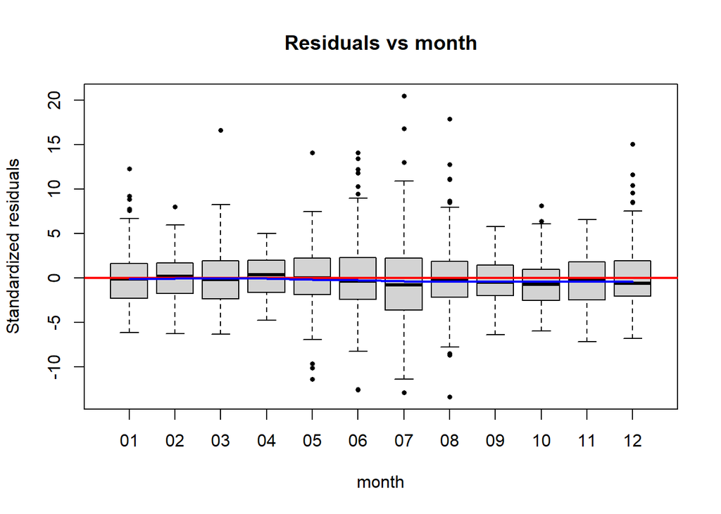

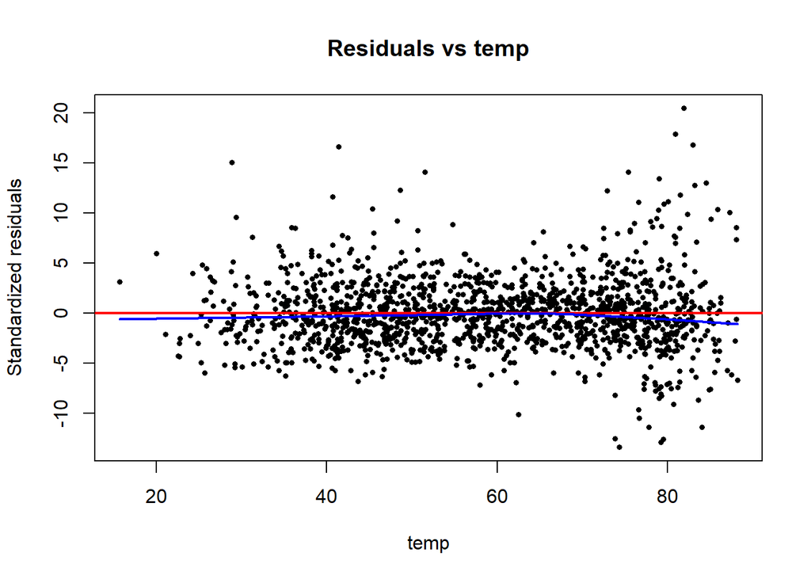

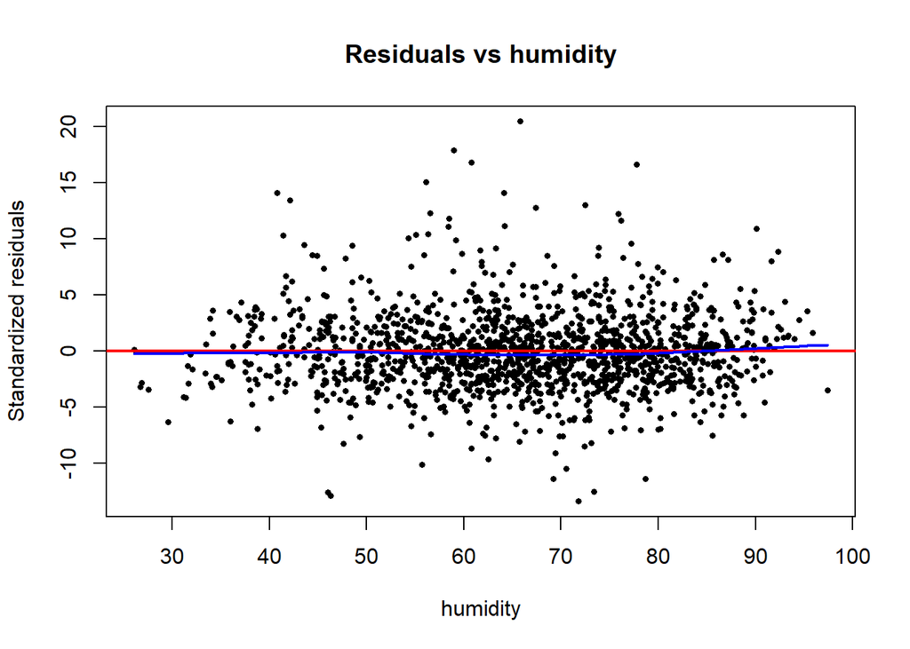

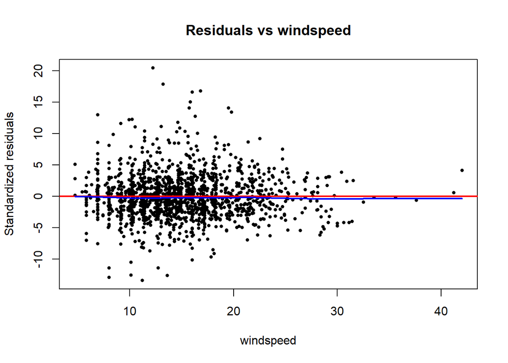

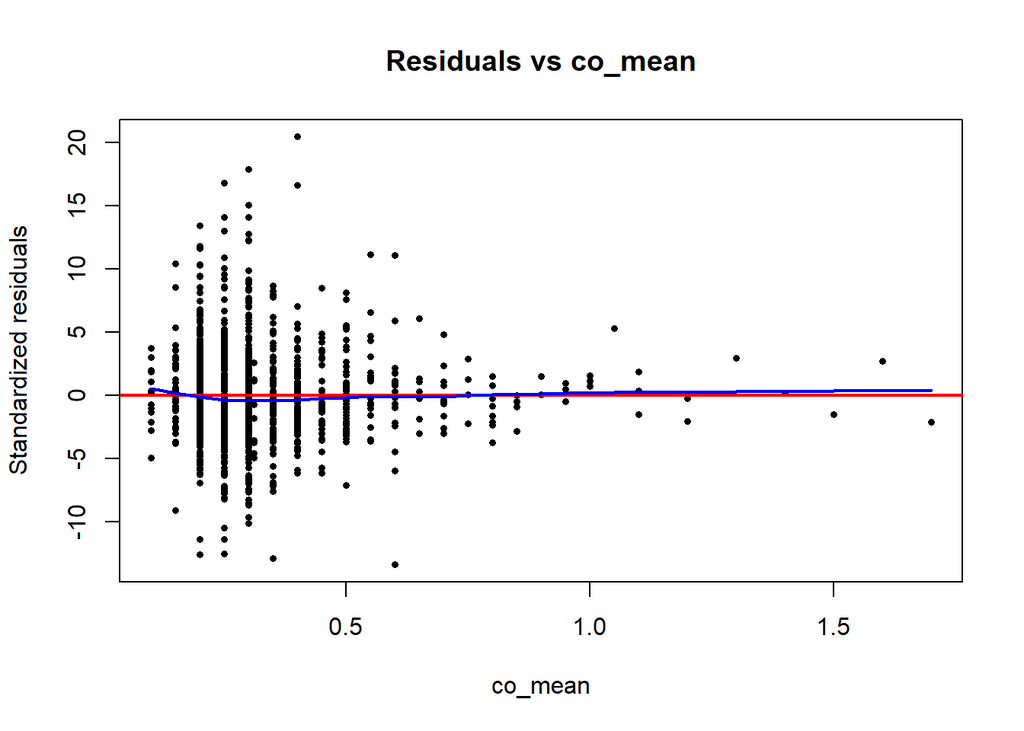

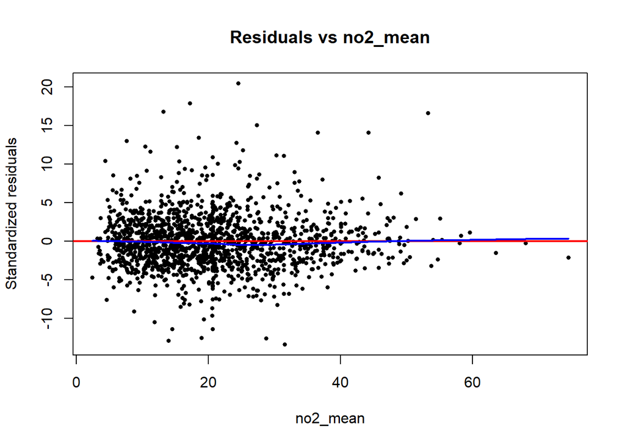

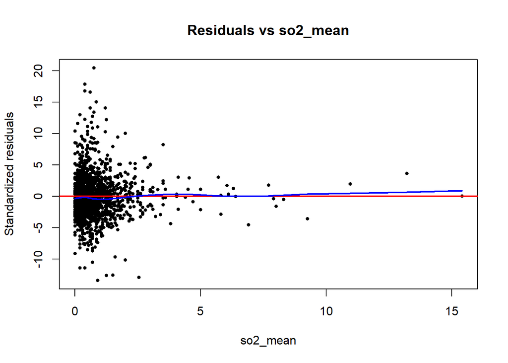

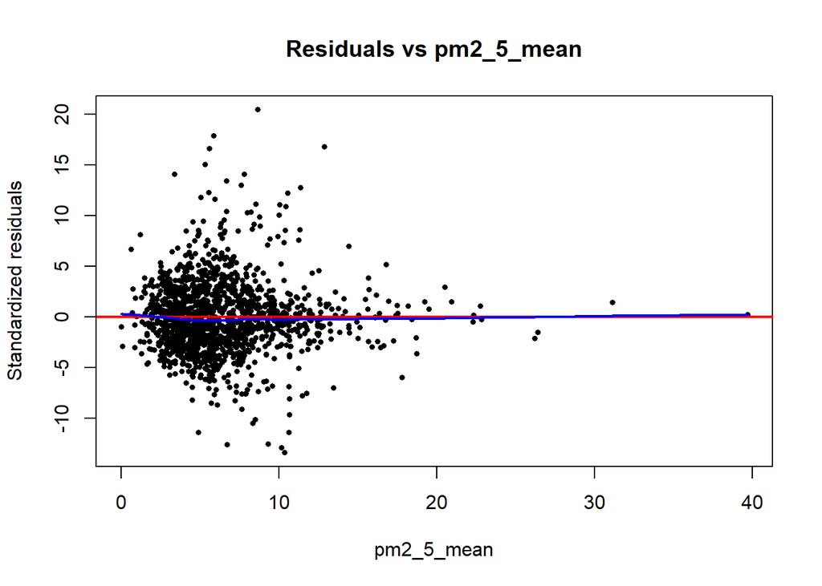

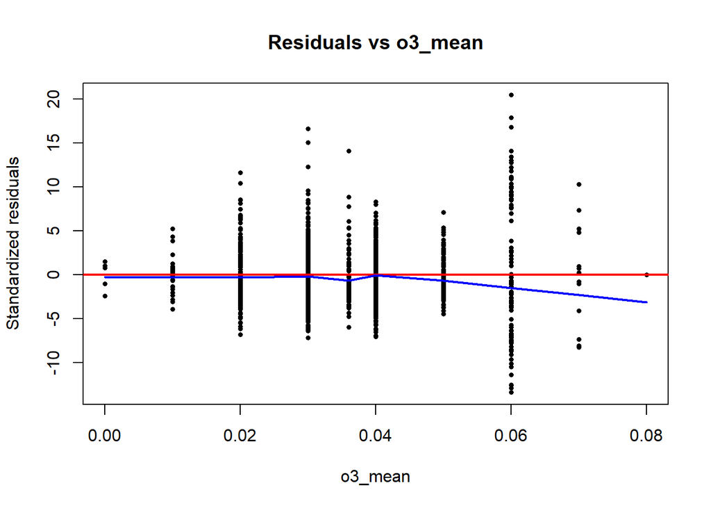

```r
# 3) residuals vs predictors (one by one)

train_full$city <- factor(train_full$city)
Xcols <- c("city", "month", "temp","humidity","windspeed",
           "co_mean","no2_mean","so2_mean","pm2_5_mean","o3_mean")

for (x in Xcols) {
  xx <- train_full[[x]]
  ok <- is.finite(xx) & is.finite(rstd_gam_int3)

  plot(xx[ok], rstd_gam_int3[ok], pch=16, cex=0.6,
       xlab=x, ylab="Standardized residuals",
       main=paste("Residuals vs", x))
  abline(h=0, col="red", lwd=2)
  lines(lowess(xx[ok], rstd_gam_int3[ok]), col="blue", lwd=2)
}
```

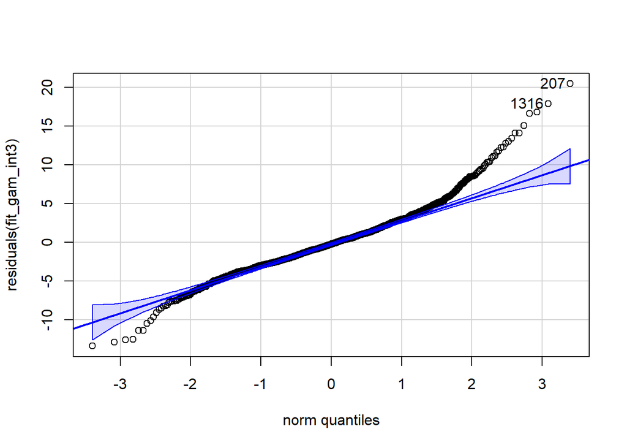

```
## [1]  207 1316
```

```r
qqPlot(residuals(fit_gam_int3))
```

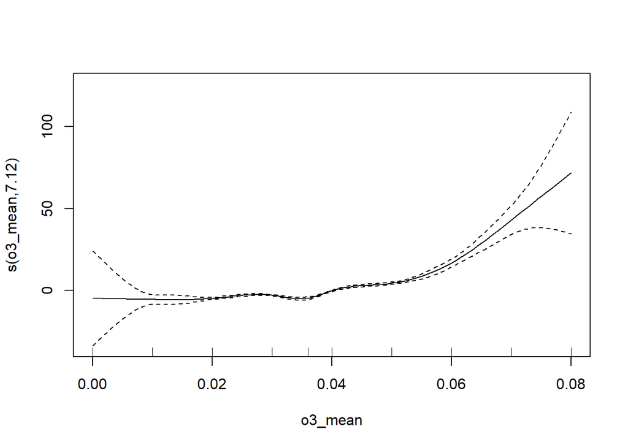

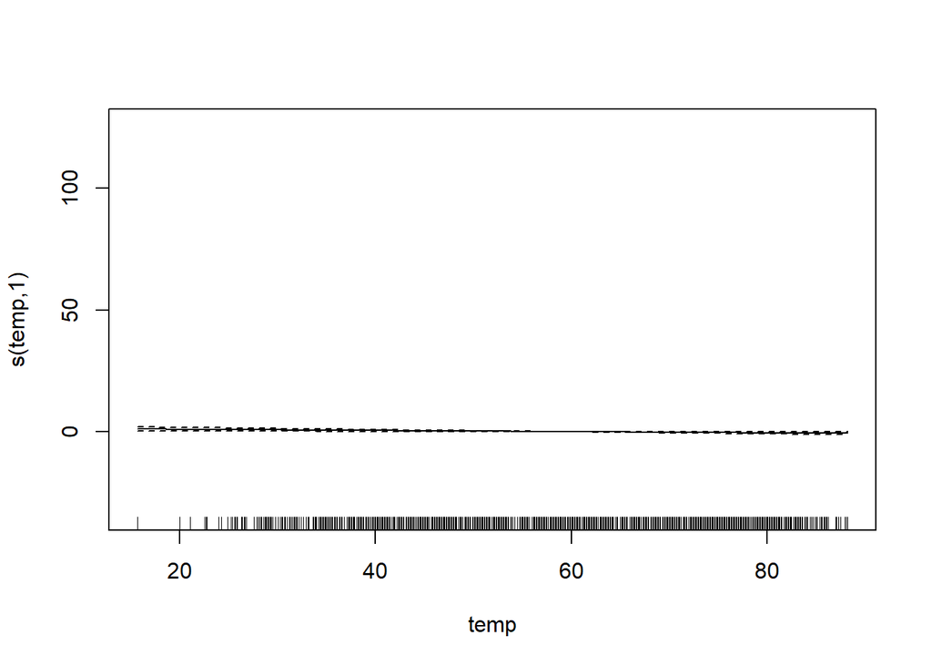

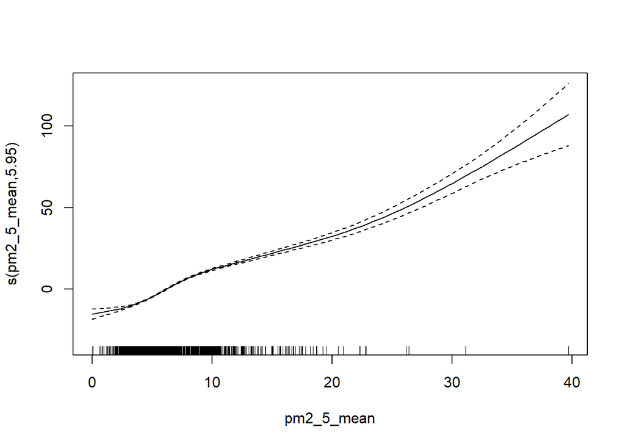

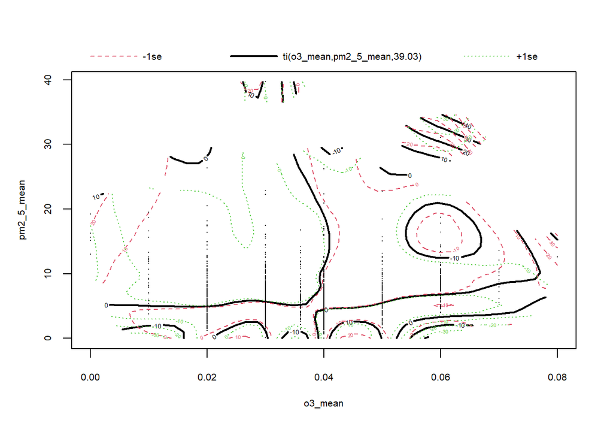

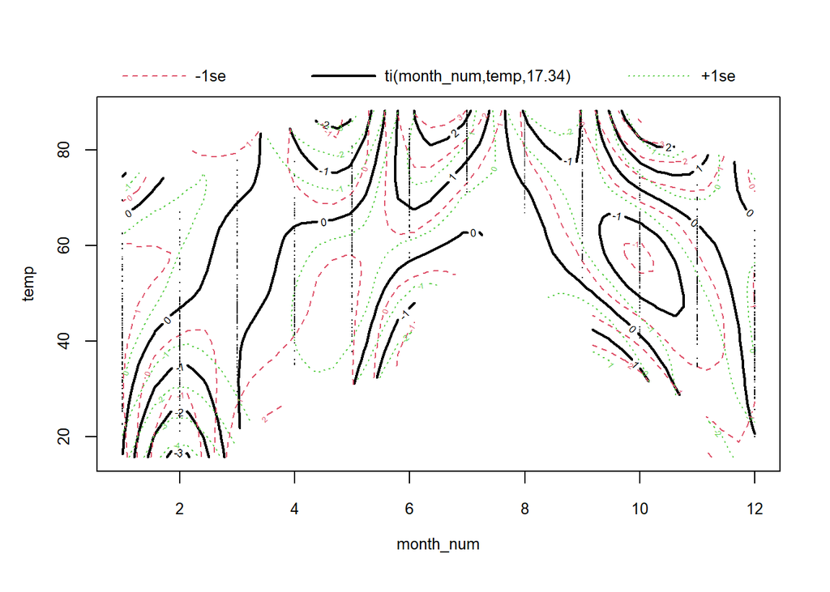

```r
plot(fit_gam_int3, shade = TRUE, shade.col = "lightblue")
```

```r
pred_gam_int3 <- predict(fit_gam_int3, newdata = test_full)

rmse_fit_gam_int3 <- rmse(test_full$max_aqi, pred_gam_int3)
rmse_fit_gam_int3
```

```
## [1] 4.287344
```

```r
resid_gam_init3 <- test_full$max_aqi - pred_gam_int3
rse_fit_gam_init3 <- sqrt(sum(resid_gam_init3^2, na.rm = TRUE) / (sum(!is.na(resid_gam_init3)) - 1))
rse_fit_gam_init3
```

```
## [1] 4.288809
```

# 10 GAM interaction BOX_COX with pollutant and temp

**gam_int_bc** is a Box-Cox-transformed GAM for AQI (y_bc) that includes city fixed effects, nonlinear smooth main effects for PM2.5, O₃, SO₂, and temperature, linear effects for NO₂, CO, humidity, and wind speed, and two nonlinear interaction surfaces: O₃ × PM2.5 and month × temperature.

```r
gam_int_bc <- update(fit_gam_k_bc, .~.
                + ti(o3_mean, pm2_5_mean, k=c(10,8))
                + ti(month_num, temp, bs=c("cc", "tp"), k=c(12,5)))

summary(gam_int_bc)
```

```
##
## Family: gaussian
## Link function: identity
##
## Formula:
## y_bc ~ city + s(pm2_5_mean, k = 8) + s(o3_mean, k = 10) + s(so2_mean,
##     k = 8) + s(temp, k = 5) + no2_mean + co_mean + humidity +
##     windspeed + ti(o3_mean, pm2_5_mean, k = c(10, 8)) + ti(month_num,
##     temp, bs = c("cc", "tp"), k = c(12, 5))
##
## Parametric coefficients:
##               Estimate Std. Error t value Pr(>|t|)
## (Intercept)  9.9328115  0.1012385  98.113  < 2e-16 ***
## cityErie    -0.3654753  0.0388135  -9.416  < 2e-16 ***
## cityMonroe  -0.2264217  0.0431396  -5.249 1.77e-07 ***
## cityQueens  -0.1604549  0.0347408  -4.619 4.22e-06 ***
## no2_mean     0.0046654  0.0018410   2.534   0.0114 *
## co_mean     -0.1845246  0.1258670  -1.466   0.1429
## humidity     0.0006667  0.0010177   0.655   0.5125
## windspeed    0.0025060  0.0026856   0.933   0.3509
## ---
## Signif. codes:  0 '***' 0.001 '**' 0.01 '*' 0.05 '.' 0.1 ' ' 1
##
## Approximate significance of smooth terms:
##                           edf Ref.df       F p-value
## s(pm2_5_mean)           6.095  6.626 533.144 < 2e-16 ***
## s(o3_mean)              7.148  7.290 110.758 < 2e-16 ***
## s(so2_mean)             1.000  1.000   0.646 0.42166
## s(temp)                 1.000  1.000   8.808 0.00305 **
## ti(o3_mean,pm2_5_mean) 38.989 42.662  25.609 < 2e-16 ***
## ti(month_num,temp)     17.469 40.000   2.220 < 2e-16 ***
## ---
## Signif. codes:  0 '***' 0.001 '**' 0.01 '*' 0.05 '.' 0.1 ' ' 1
##
## R-sq.(adj) =  0.929   Deviance explained = 93.2%
## GCV = 0.20538  Scale est. = 0.1942    n = 1464
```

You fitted a Gaussian GAM (identity link) where the response is $ybc$ the Box–Cox–transformed version of max_aqi. So the model is explaining AQI on a transformed scale to make residuals closer to normal and variance more stable.

**Parametric (linear) part**

- **Intercept = 9.933**: baseline transformed AQI for the reference city (Bronx) when numeric predictors are zero (mainly a baseline anchor).
- **City effects**: Erie (-0.365), Monroe (-0.226), and Queens (-0.160) are significantly lower than Bronx (extremely small p-values), indicating Bronx retains the highest baseline after correcting for pollutants and weather.
- **no2_mean**:NO₂ continues to provide a substantial positive contribution (+0.004, p=0.01).
- **CO_mean**: −0.185(p=0.143) doesnot show any significance.
- **Humidity and windspeed**: They are not substantial in this case, therefore they can add a very little independent signal once the smooths/interactions are taken into account.

**Smooth terms (nonlinear effects)**

- **s(pm2_5_mean)** is the strongest main driver (edf ≈ 6.095, huge F, p<2e−16): PM2.5 affects AQI in a clearly nonlinear way.
- **s(o3_mean)** is also very strong (edf ≈ 7.148, p<2e−16): ozone has an important nonlinear relationship with AQI.
- **s(temp)** is significant but effectively linear (edf = 1, p=0.00305): temperature matters, but the shape doesn’t need much curvature.
- **s(so2_mean)** is not significant (p=0.42, edf=1): SO₂ provides little additional explanatory power in this model.

**interaction surfaces**

- **ti(o3_mean, pm2_5_mean)** is extremely significant (edf ≈ 38.98, p<2e−16): the impact of ozone depends strongly on PM2.5 levels (and vice versa), capturing “combined pollution” behavior.
- **ti(month, temp)** is significant (edf ≈ 17.46): the temperature–AQI relationship changes across months (seasonal modulation).
- **Adj. $R^2$** is 0.929 and Deviance explained = $93.2\%$: excellent fit—this model explains most of the variability in AQI (on the Box–Cox scale).
- **Scale est.** is 0.1942, residual variance on the transformed scale (smaller is better here, and often improves with Box–Cox).